# Waste Classification

Agostino Tassan Mazzocco, Andrea Sorgente, Gianluca Borchielli

5/5/2022

## Data Preparation

```r
knitr::opts_chunk$set(echo = TRUE)
library(keras)
```

Scelta della directory dei dati originali.

```r
original_dataset_dir_tr_O <- "/Users/Ago/Desktop/Magistrale/Data Mining/Intro to Deep Learning/Progetto/OriginalDirectory/TRAIN/O"
original_dataset_dir_tr_R <- "/Users/Ago/Desktop/Magistrale/Data Mining/Intro to Deep Learning/Progetto/OriginalDirectory/TRAIN/R"
original_dataset_dir_te_O <- "/Users/Ago/Desktop/Magistrale/Data Mining/Intro to Deep Learning/Progetto/OriginalDirectory/TEST/O"
original_dataset_dir_te_R <- "/Users/Ago/Desktop/Magistrale/Data Mining/Intro to Deep Learning/Progetto/OriginalDirectory/TEST/R"
```

Scelta e creazione della directory base dove verranno create le nuove cartelle in cui inserire i dati.

```r
base_dir <- "/Users/Ago/Desktop/Magistrale/Data Mining/Intro to Deep Learning/Progetto/Dati2"
dir.create(base_dir)
```

Creazione delle cartelle in cui verranno inseriti i dati di training, validation e test per ognuna delle due classi “O” e “R”.

```r
train_dir <- file.path(base_dir, "train")
dir.create(train_dir)
validation_dir <- file.path(base_dir, "validation")
dir.create(validation_dir)
test_dir <- file.path(base_dir, "test")
dir.create(test_dir)
train_O_dir <- file.path(train_dir, "O")
dir.create(train_O_dir)
train_R_dir <- file.path(train_dir, "R")
dir.create(train_R_dir)
validation_O_dir <- file.path(validation_dir, "O")
dir.create(validation_O_dir)
validation_R_dir <- file.path(validation_dir, "R")
dir.create(validation_R_dir)
test_O_dir <- file.path(test_dir, "O")
dir.create(test_O_dir)
test_R_dir <- file.path(test_dir, "R")
dir.create(test_R_dir)
```

Estrazione degli indici delle immagini che andranno a far parte del trainng, del validation e del test set, per ognuna delle due classi.

```r
set.seed(123)
ind_tr <- matrix(c(1:13968))
tr_ind_O <- sample(c(1:201,203:4429,4431:13968), 8000)
val_ind_O <- sample(ind_tr[-c(tr_ind_O,202,4430),],2000)
te_ind_O <- sample(ind_tr[-c(val_ind_O,tr_ind_O,202,4430),],1000)
tr_ind_R <- sample(1:11111, 8000)
val_ind_R <- sample(matrix(1:11111)[-tr_ind_R,], 2000)
te_ind_R <- sample(matrix(1:11111)[-c(tr_ind_R,val_ind_R),],1000)
```

Copiamo le immagini selezionate nelle rispettive directory precedentemente create.

```r
fnames <- paste0("O_", tr_ind_O, ".jpg")
for (i in tr_ind_O) {
  if(i<=12567) file.copy(file.path(original_dataset_dir_tr_O, fnames[which(tr_ind_O==i)]),file.path(train_O_dir))
  else file.copy(file.path(original_dataset_dir_te_O, fnames[which(tr_ind_O==i)]),file.path(train_O_dir))
}
fnames <- paste0("O_", val_ind_O, ".jpg")
for (i in val_ind_O) {
  if(i<=12567) file.copy(file.path(original_dataset_dir_tr_O, fnames[which(val_ind_O==i)]),file.path(validation_O_dir))
  else file.copy(file.path(original_dataset_dir_te_O, fnames[which(val_ind_O==i)]),file.path(validation_O_dir))
}
fnames <- paste0("O_", te_ind_O, ".jpg")
for (i in te_ind_O) {
  if(i<=12567) file.copy(file.path(original_dataset_dir_tr_O, fnames[which(te_ind_O==i)]),file.path(test_O_dir))
  else file.copy(file.path(original_dataset_dir_te_O, fnames[which(te_ind_O==i)]),file.path(test_O_dir))
}
fnames <- paste0("R_", tr_ind_R, ".jpg")
for (i in tr_ind_R) {
  if(i<=9999) file.copy(file.path(original_dataset_dir_tr_R, fnames[which(tr_ind_R==i)]),file.path(train_R_dir))
  else file.copy(file.path(original_dataset_dir_te_R, fnames[which(tr_ind_R==i)]),file.path(train_R_dir))
}
fnames <- paste0("R_", val_ind_R, ".jpg")
for (i in val_ind_R) {
  if(i<=9999) file.copy(file.path(original_dataset_dir_tr_R, fnames[which(val_ind_R==i)]),file.path(validation_R_dir))
  else file.copy(file.path(original_dataset_dir_te_R, fnames[which(val_ind_R==i)]),file.path(validation_R_dir))
}
fnames <- paste0("R_", te_ind_R, ".jpg")
for (i in te_ind_R) {
  if(i<=9999) file.copy(file.path(original_dataset_dir_tr_R, fnames[which(te_ind_R==i)]),file.path(test_R_dir))
  else file.copy(file.path(original_dataset_dir_te_R, fnames[which(te_ind_R==i)]),file.path(test_R_dir))
}
```

In totale abbiamo ottenuto:

```
## total training O images: 8000
```

```
## total training R images: 8000
```

```
## total validation O images: 2000
```

```
## total validation R images: 2000
```

```
## total test O images: 1000
```

```
## total test R images: 1000
```

##Feed Forward Neural Network Pre-processing delle immagini che verranno riscalate nell’intervallo [0,1]

```r
train_datagen <- image_data_generator(rescale = 1/255)
```

```
## Loaded Tensorflow version 2.8.0
```

```r
validation_datagen <- image_data_generator(rescale = 1/255)
```

Generazione dei dati di training che vengono trasformati in un tensore di dimensione (16000,224,224,3) e divisi in batches formati da 128 immagini ciascuno e riscalati secondo i comandi precedenti. Lo stesso viene effettuato per il validation, che viene diviso in batches composti da 32 immagini.

```r
train_generator <- flow_images_from_directory(
  train_dir,
  train_datagen,
  target_size = c(224,224),
  batch_size = 128,
  class_mode = "binary"
)
validation_generator <- flow_images_from_directory(
  validation_dir,
  validation_datagen,
  target_size = c(224,224),
  batch_size = 32,
  class_mode = "binary"
)
```

```r
model_FFN <- keras_model_sequential() %>%
  layer_flatten() %>%
  layer_dense(units = 128, activation = "relu") %>%
  layer_dense(units = 64, activation = "relu") %>%
  layer_dense(units = 1, activation = "sigmoid")
```

Il modello viene compilato impostando l’ottimizzatore “rmsprop”, la loss function “binary crossentropy” e come metrica di valutazione l’accuratezza della classificazione.

```r
model_FFN %>% compile(
  optimizer = optimizer_rmsprop(lr = 1e-4),
  loss = "binary_crossentropy",
  metrics = c("accuracy")
)
```

Prima di allenare la rete scegliamo il criterio di early stopping. L’allenamento della rete si interromperà quando per 5 epoche consecutive l’accuracy del validation set non aumenterà si almeno 0.005.

```r
early_stopping <- callback_early_stopping(monitor = "val_accuracy",
                                          min_delta = 0.005,
                                          patience = 5, mode = "max")
```

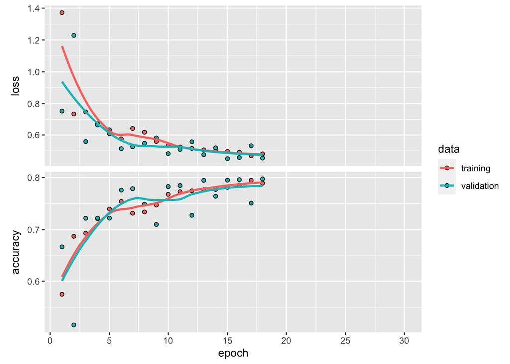

```r
history_FFN <- model_FFN %>% fit(
  train_generator, callbacks = early_stopping,
  epochs = 30,
  steps_per_epoch = 125,
  validation_data = validation_generator,
  validation_steps = 125
)
plot(history_FFN)
```

##Convolutional Neural Network Preprocessing dei dati equivalente alla rete precedente.

```r
train_datagen <- image_data_generator(rescale = 1/255)
validation_datagen <- image_data_generator(rescale = 1/255)
train_generator <- flow_images_from_directory(
  train_dir,
  train_datagen,
  target_size = c(224, 224),
  batch_size = 128,
  class_mode = "binary"
)
validation_generator <- flow_images_from_directory(
  validation_dir,
  validation_datagen,
  target_size = c(224,224),
  batch_size = 32,
  class_mode = "binary"
)
```

Costruzione della rete neurale convoluzionale, composta da 3 layers convoluzionali composti rispettivamente da 32, 64 e 128 filtri di dimensione 3x3, alternati con altrettanti layers di max pooling di dimensione 2x2, infine sono stati aggiunti 2 layers densi con rispettivamente 128 e 64 neuroni e un output layer. Le funzioni di attivazione utilizzate sono la “ReLU” e la “sigmoid” per l’output layer.

```r
model_CNN <- keras_model_sequential() %>%
  layer_conv_2d(filters = 32, kernel_size = c(3, 3), activation = "relu",
                input_shape = c(224, 224, 3)) %>%
  layer_max_pooling_2d(pool_size = c(2, 2)) %>%
  layer_conv_2d(filters = 64, kernel_size = c(3, 3), activation = "relu") %>% layer_max_pooling_2d(pool_size = c(2, 2)) %>%
  layer_conv_2d(filters = 128, kernel_size = c(3, 3), activation = "relu") %>% layer_max_pooling_2d(pool_size = c(2, 2)) %>%
  layer_flatten() %>%
  layer_dense(units = 128, activation = "relu") %>%
  layer_dense(units = 64, activation = "relu") %>%
  layer_dense(units = 1, activation = "sigmoid")
```

Compiliamo il modello con ottimizzatore, loss function e metrica, prima di addestrare la rete per un massimo di 30 epoche utilizzando lo stesso metodo di early stopping utilizzato precedentemente.

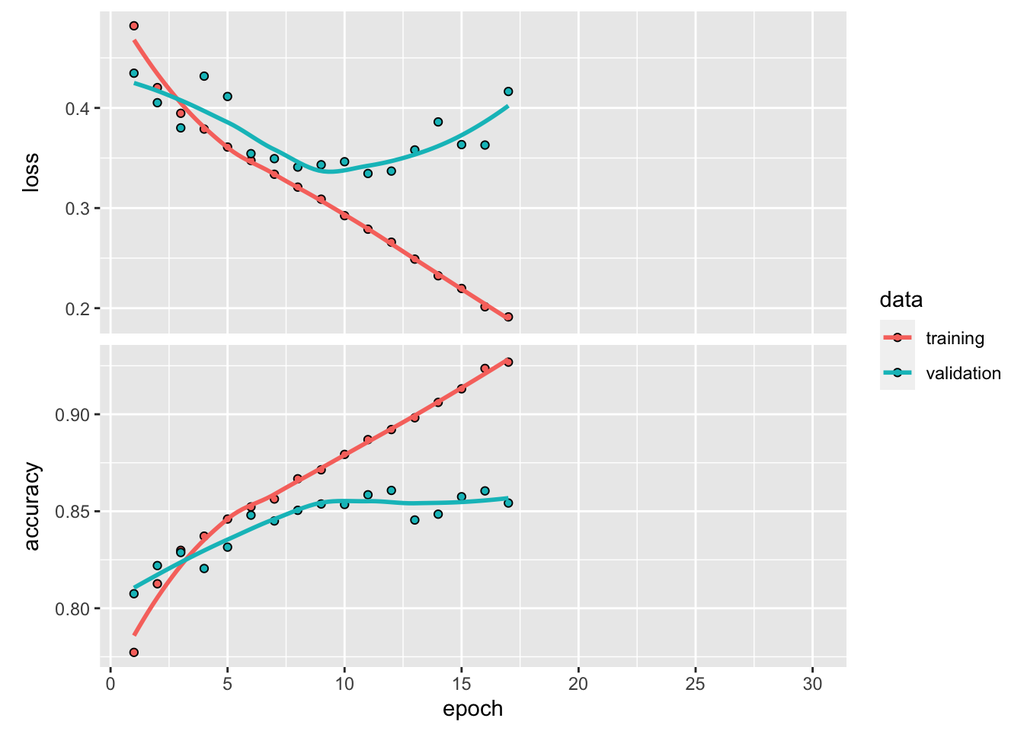

```r
model_CNN %>% compile(
  loss = "binary_crossentropy",
  optimizer = optimizer_rmsprop(lr = 1e-4),
  metrics = c("accuracy")
)
early_stopping <- callback_early_stopping(monitor = "val_accuracy",
                                          min_delta = 0.005,
                                          patience = 5, mode = "max")
history_CNN <- model_CNN %>% fit_generator(
  train_generator, callbacks = early_stopping,
  steps_per_epoch = 125,
  epochs = 30,
  validation_data = validation_generator,
  validation_steps = 125
)
plot(history_CNN)
```

##Data Augmentation Per limitare il problema dell’overfitting, utilizziamo la tecnica della data augmentation che genera nuove osservazioni a partire da quelle del training set, tramite trasformazioni casuali. In questo caso modifichiamo la funzione di preprocessing dei dati.

```r
data_aug <- image_data_generator(
  rescale = 1/255,
  rotation_range = 40,
  width_shift_range = 0.2,
  height_shift_range = 0.2,
  shear_range = 0.2,
  zoom_range = 0.2,
  fill_mode = "nearest"
)
train_generator <- flow_images_from_directory(
  train_dir,
  data_aug,
  target_size = c(224, 224),
  batch_size = 128,
  class_mode = "binary"
)
validation_generator <- flow_images_from_directory(
  validation_dir,
  validation_datagen,
  target_size = c(224, 224),
  batch_size = 32,
  class_mode = "binary"
)
```

La rete neurale è identica alla rete convoluzionale precedentemente costruita, con l’aggiunta del dropout per evitare ulteriormente il problema dell’overfitting.

```r
model_AUG <- keras_model_sequential() %>%
  layer_conv_2d(filters = 32, kernel_size = c(3, 3), activation = "relu",
                input_shape = c(224, 224, 3)) %>%
  layer_max_pooling_2d(pool_size = c(2, 2)) %>%
  layer_conv_2d(filters = 64, kernel_size = c(3, 3), activation = "relu") %>% layer_max_pooling_2d(pool_size = c(2, 2)) %>%
  layer_conv_2d(filters = 128, kernel_size = c(3, 3), activation = "relu") %>% layer_max_pooling_2d(pool_size = c(2, 2)) %>%
  layer_flatten() %>%
  layer_dropout(rate = 0.5) %>%
  layer_dense(units = 128, activation = "relu") %>%
  layer_dense(units = 64, activation = "relu") %>%
  layer_dense(units = 1, activation = "sigmoid")
```

Per quanto riguarda la compilazione del modello e il criterio di early stopping si fa riferimento alla rete convoluzionale precedentemente costruita.

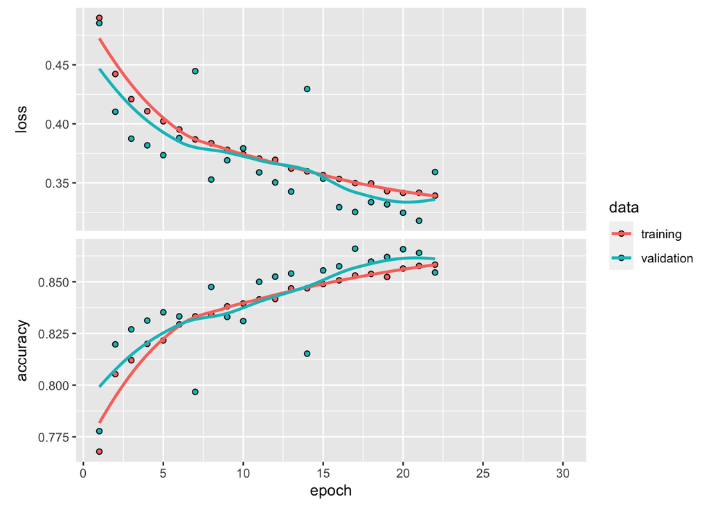

```r
model_AUG %>% compile(
  loss = "binary_crossentropy",
  optimizer = optimizer_rmsprop(lr = 1e-4),
  metrics = c("accuracy")
)
early_stopping <- callback_early_stopping(monitor = "val_accuracy",
                                          min_delta = 0.005,
                                          patience = 5, mode = "max")
history_AUG <- model_AUG %>% fit_generator(
  train_generator, callbacks = early_stopping,
  steps_per_epoch = 125,
  epochs = 30,
  validation_data = validation_generator,
  validation_steps = 125
)
plot(history_AUG)
```

##VGG-16 Utilizziamo la rete pre-allenata VGG-16. Scarichiamo la rete prendendo solo gli strati convoluzionali.

```r
conv_base <- application_vgg16(
  weights = "imagenet",
  include_top = FALSE,
  input_shape = c(224, 224, 3)
)
```

Facciamo feature extraction sui nostri dati sfruttando la rete pre-allenata per ricavare nuove informazioni dalle immagini.

```r
datagen <- image_data_generator(rescale = 1/255)
extract_features <- function(directory, sample_count, batch_size) {

  features <- array(0, dim = c(sample_count, 7, 7, 512))
  labels <- array(0, dim = c(sample_count))

  generator <- flow_images_from_directory(
    directory = directory,
    generator = datagen,
    target_size = c(224, 224),
    batch_size = batch_size,
    class_mode = "binary"
  )

  i <- 0
  while(TRUE) {
    batch <- generator_next(generator)
    inputs_batch <- batch[[1]]
    labels_batch <- batch[[2]]
    features_batch <- conv_base %>% predict(inputs_batch)
    index_range <- ((i * batch_size)+1):((i + 1) * batch_size)
    features[index_range,,,] <- features_batch
    labels[index_range] <- labels_batch

    i <- i + 1

    if (i * batch_size >= sample_count)
      break
  }

  list(
    features = features,
    labels = labels
  )
}


train <- extract_features(train_dir, 16000, 64)
validation <- extract_features(validation_dir, 4000, 32)
test <- extract_features(test_dir, 2000, 20)
```

Adesso riscaliamo i dati in modo da poterli utilizzare per allenare una rete feed forward.

```r
reshape_features <- function(features) {
  array_reshape(features, dim = c(nrow(features), 7 * 7 * 512))
}
train$features <- reshape_features(train$features)
validation$features <- reshape_features(validation$features)
test$features <- reshape_features(test$features)
```

```r
model_VGG16 <- keras_model_sequential() %>%
  layer_dense(units = 512, activation = "relu",
              input_shape = 7 * 7 * 512) %>%
  layer_dense(units = 256, activation = "relu") %>%
  layer_dropout(rate = 0.5) %>%
  layer_dense(units = 1, activation = "sigmoid")
```

Compiliamo e usiamo il solito criterio di early stopping.

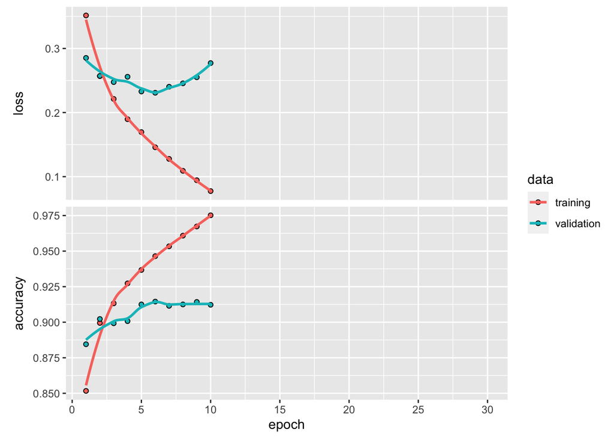

```r
model_VGG16 %>% compile(
  optimizer = optimizer_rmsprop(lr = 2e-5),
  loss = "binary_crossentropy",
  metrics = c("accuracy")
)

early_stopping <- callback_early_stopping(monitor = "val_accuracy",
                                          min_delta = 0.005,
                                          patience = 5, mode = "max")

history_VGG16 <- model_VGG16 %>% fit(
  train$features, train$labels,
  callbacks = early_stopping,
  epochs = 30,
  batch_size = 32,
  validation_data = list(validation$features, validation$labels)
)
plot(history_VGG16)
```

Applichiamo il modello ottenuto al test set per valutarne la performance.

```r
model_VGG16 %>% evaluate(test$features, test$labels)
```

```
##      loss  accuracy
## 0.3182787 0.9040000
```